# Recipes for pre-processing

Koji Mizumura

December 5th, 2018

https://github.com/topepo/user2018/tree/master/slides

# Getting started

## `recipes` and other modeling packages

`recipes` is part of growing collection of R packages that use the tenets of the `tidyverse`:

1. Reuse existing data structures
2. Compose simple functions with the pipe.
3. Embrace functional programming
4. Design for humans

This approach is exemplified by packages such as `broom`, `infer`, `rsample`, `tidyposterior`, `tidytext` and `yardstick`.

The list of packages in the `tidymodels` org continues to grow.

The more traditional approach use high-level syntax and is perhaps the most untidy code that you will encounter.

`caret` is the primary package for highly untidy predictive modeling:

1. More traditional R coding style
2. High-level “I will do that for you” syntax
3. More comprehensive (for now) and less modular
4. Contains many optimizations and is easily paralleized

Luckily, `recipes` can work with both approaches.

## Example data set - house prices

For regression problems, we will use Ames IA housing data. There are 2,930 properties in the data. The sale price was recorded along with 81 predictors, including

- Location (e.g. neighborhood) and lot information.
- House components (garage, replace, pool, porch, etc.).
- General assessments such as overall quality and condition.
- Number of bedrooms, baths, and so on.

The raw data are at http://bit.ly/2whgsQM but we will use a processed version found in the `AmesHousing` package.

## Tidyverse syntax

Many tidyverse functions have syntax unlike base R code. For example:

- vectors of variable names are eschewed in favor of *functional programming*. For example,

```r
contains("Sepal")
# instead of
c("Sepal.Width", "Sepal.Length")
```

- The `pipe` oerator is preferred. For example

```r
merged <- inner_join(a,b)
# is equal to
merge <- a %>%
  inner_join(b)
```

- Functions are more *modular* than their traditional analogs (`dplyr`’s `filter` and `select` vs `base::subset`)

## Some example data manipulation code

```r
library(tidyverse)
library(AmesHousing)


# ames <-
#   read_delim("AmesHousing::ames_raw", delim = "\t") %>%
#   rename_at(vars(contains(' ')), funs(gsub(' ', '_', .))) %>%
#   rename(Sale_Price = SalePrice) %>%
#   filter(!is.na(Electrical)) %>%
#   select(-Order, -PID, -Garage_Yr_Blt)

ames <- ames_raw %>%
  rename_at(vars(contains(' ')), funs(gsub(' ', '_', .))) %>%
  rename(Sale_Price=SalePrice) %>%
  filter(!is.na(Electrical)) %>%
  select(-Order,-PID, -Garage_Yr_Blt)

ames %>%
  group_by(Alley) %>%
  summarise(mean_price=mean(Sale_Price/1000),
            n=sum(!is.na(Sale_Price)))
```

```
## # A tibble: 3 x 3
##   Alley mean_price     n
##   <chr>      <dbl> <int>
## 1 Grvl        124.   120
## 2 Pave        177.    78
## 3 <NA>        183.  2731
```

## Example `ggplot2` code

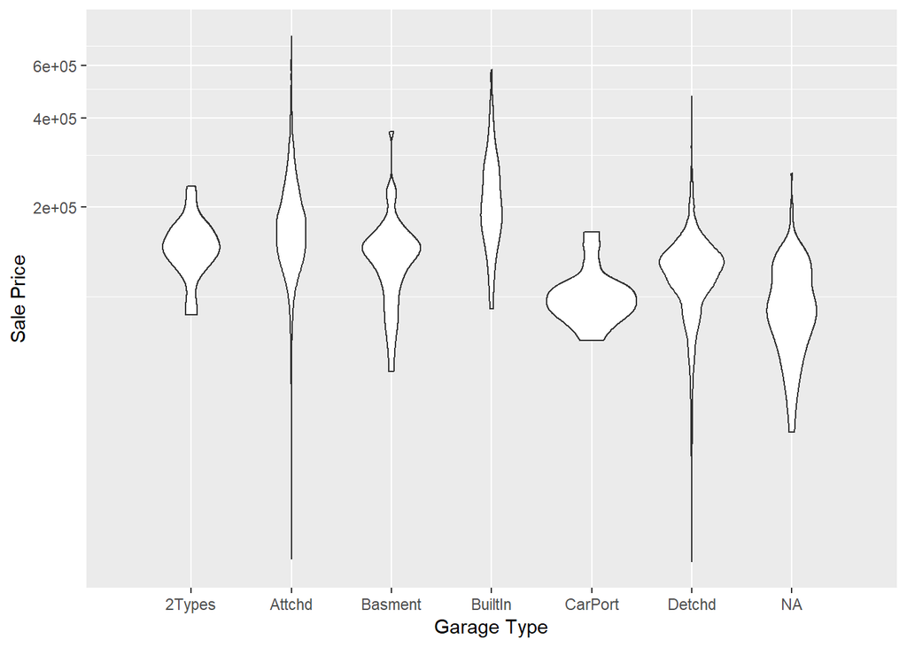

```r
library(ggplot2)

ggplot(ames,
       aes(
         x=Garage_Type,
         y=Sale_Price))+
  geom_violin()+
  coord_trans(y="log10")+
  xlab("Garage Type")+
  ylab("Sale Price")
```

## Examples of `purrr::map*`

```r
library(purrr)

# summarize via purrr:map
by_alley <- split(ames,ames$Alley)
is_list(by_alley)
```

```
## [1] TRUE
```

```r
map(by_alley, nrow)
```

```
## $Grvl
## [1] 120
##
## $Pave
## [1] 78
```

```r
# or better yet:
map_int(by_alley, nrow)
```

```
## Grvl Pave
##  120   78
```

```r
# works on non-list vectors too

ames %>%
  mutate(Sale_Price=Sale_Price %>%
           map_dbl(function(x) x/1000)) %>%
  select(Sale_Price, Yr_Sold) %>%
  head(4)
```

```
## # A tibble: 4 x 2
##   Sale_Price Yr_Sold
##        <dbl>   <int>
## 1        215    2010
## 2        105    2010
## 3        172    2010
## 4        244    2010
```

## Reasons for modifying the data

- Some models (K-NN, SVMs, PLS, neural networks) require that the predictor variables have the same units. **Centering** and **scaling** the predictors can be used for this purpose.
- Other models are very sensitive to correlations between the predictors and lters or **PCA signal extraction** can improve the model.
- As we’ll see an an example, changing the scale of the predictors using a **transformation** can lead to a big improvement.
- In other cases, the data can be **encoded** in a way that maximizes its effect on the model. Representing the date as the day or the week can be very effective for modeling public transportation data.
- Many models cannot cope with missing data so **imputation** strategies might be necessary.
- Development of new features that represent something important to the outcome (e.g. compute distances to public transportation, university buildings, public schools, etc.)

## A Bivariate example

Some models might be sensitive to highly correlated and/or skewed predictors. Isthere something that we can do to make the predictors easier for the model to use?

We might start by estimating transformations of the predictors to resolve the skewness. The Box-Cox transformation is a family of transformations orginally designed for the outcomes of models. We can use it ere for the predictors.

IT uses the data to estimate a wide variety of transformations including the inverse, log, sqrt, and polynomial functions.

# Preprocessing categorical predictors

## Ames data

The`AmesHousing` package has a better version of the data that has been cleaned up and includes geocodes for the properties. Let’s load that and use the `rsample` package to make a split of the data where 3/4 goes into training set:

```r
library(AmesHousing)
ames <- make_ames()

dim(ames)
```

```
## [1] 2930   81
```

```r
library(rsample)
# make sure that you get the same random numbers
set.seed(4595)
data_split <- initial_split(ames,strata="Sale_Price")

ames_train <- training(data_split)
ames_test <- testing(data_split)
```

## Dummy variables

One common procedure for modeling is to create numeric representatios of categorical data. This is usually done via *dummy variables*: a set of binary 0/1 variables for different levels of an R factor:

If there are C levels of the facor, only C-1 dummy variables are created since the last can be inferred from the others. There are different contrast schemes for creating the new variables.

For ordered factors, `polynomial contrasts` are used.

The formula method does this for you. Otherwise, the traditional method is to use the `model.matrix` function[^1] to create a matrix. However, there are some caveats to this that can make things difficult.

We’ll show another method for making them shortly.

*[1]: Almost always at least. Tree- and rule-based model functions do not. Examples are `randomforest::randomForest`, `ranger::ranger`, `rpart::rpart`, `C50::C5.0`, `Cubist::cubist`, `klaR::NaiveBayes`and others.

## Infrequent levels in categorical factors

One issue is: what happens when there are very few values of a level?

Consider the Ames training set and the `Neighborhood` variable. If these data are resampled, what would happen to Landmark and similar locations when dummy variables are created?

A zero-variance predictor that has only a single value (zero) would be the result. For many models (e.g., linear/logistic regression etc.) would find this numerically problematic and issue a warning and `NA` values for that coefficient and similar models would not notice.

There are two main approaches to dealing with this:  
1) Run a filter on the training set predictors prior to running the model and remove the zero-variance predictors. 2) Recode the factor so that infrequenty occuring predictors (and possible new values) are pooled into an “other” category.

However, `model.matrix` add the formula method are incapable of doing either of these.

## Other approaches

A few other approaches that might help here:

- *effect* or *likelihood encodings* of categorical predictors estimate the mean effect of the outcome for every factor level in the predictor. These estimates are used in place of the factor levels. Shrinkage /regulaization can improve these approaches.
- *entity embeddings* use a nerual network to create features that capture the relationships between the categories and the categories and the outcome.

An add-on to `recipes` called `embeded` can be used for these encodings.

# Creating Recipes

## Recipes

Recipes are an alternative method for creating the data frame of predictors for a model. They allow for a sequence of steps that define how data should be handled. Suppose we use the formula `log10(Sale_Price)~Longitude+Latitude`? These steps are:

- Assign `Sale_Price` to be the outcome
- Assign `Longitude` and `Latitude` are predictors
- Log transform the outcome

To start using a recipe, the these steps can be done using

```r
library(recipes)

mod_rec <- recipe(Sale_Price~Longitude+Latitude,
                  data=ames_train) %>%
  step_log(Sale_Price,base=10)

mod_rec
```

```
## Data Recipe
##
## Inputs:
##
##       role #variables
##    outcome          1
##  predictor          2
##
## Operations:
##
## Log transformation on Sale_Price
```

this creates the recipe for data processing (but does not execute it yet).

## Recipes and categorical predictors

To deal with the dummy variable issue, we can expand the recipe with more steps:

```r
mod_rec <- recipe(Sale_Price~Longitude+Latitude+Neighborhood, data=ames_train) %>%
  step_log(Sale_Price, base=10) %>%
  # lump factor levels that occur in <= 5% of data as "others"
  step_other(Neighborhood, threshold=0.05) %>%
  # create dummy variables for _any_factor variables
  step_dummy(all_nominal())
```

note that we can use standard `dplyr` selectors as well as some new ones based on the data type (`all_nomial()`) or by their role in the analysis (all_predictors()).

The general process for using recipes is

```
recipes --> prep() --> bake/juice
(define) --> (estimate) --> (apply)
```

## Preparing the recipe

Now that we have apreprocessing `specification`, let’s run it on the training set to *prepare* the recipe:

```r
mod_rec_trained <- prep(mod_rec, training=ames_train, retain=T, verbose=T)
```

```
## oper 1 step log [training]
## oper 2 step other [training]
## oper 3 step dummy [training]
## The retained training set is ~ 0.19 Mb  in memory.
```

Here, the “training” is to determine which factors to pool and to enumerate the factor levels of the `Neighborhood` variable, `retain` keeps the processed version of the training set around so we don’t have to recompute it.

```r
mod_rec_trained
```

```
## Data Recipe
##
## Inputs:
##
##       role #variables
##    outcome          1
##  predictor          3
##
## Training data contained 2199 data points and no missing data.
##
## Operations:
##
## Log transformation on Sale_Price [trained]
## Collapsing factor levels for Neighborhood [trained]
## Dummy variables from Neighborhood [trained]
```

## Getting the values

Once the recipe is prepared, it can be applied to any data set using `bake`:

```r
ames_test_dummies <-  bake(mod_rec_trained, newdata=ames_test)
names(ames_test_dummies)
```

```
##  [1] "Sale_Price"                      "Longitude"
##  [3] "Latitude"                        "Neighborhood_College_Creek"
##  [5] "Neighborhood_Old_Town"           "Neighborhood_Edwards"
##  [7] "Neighborhood_Somerset"           "Neighborhood_Northridge_Heights"
##  [9] "Neighborhood_Gilbert"            "Neighborhood_Sawyer"
## [11] "Neighborhood_other"
```

If `retain=TRUE` the training set does not to be “rebaked”. The `juice` function can retrun the processed version of the training data. Selectors can be used with `bake` and the default is `everything()`.

# Interaction effects

## Interactions

An `interactions` between two predictors indicates that the relationship between the predictors and the outcome cannot be described using only one of the variables.

For example, let’s look at the relationship between the price of a house and the year in which it was built. The relationship appears to be slightly nonlinear, possible quadratic.

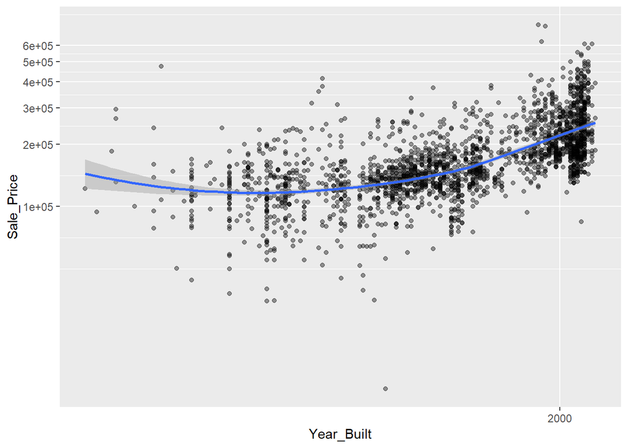

```r
price_breaks <- (1:6)*(10^5)

ggplot(ames_train,
       aes(x=Year_Built, y=Sale_Price))+
  geom_point(alpha=0.4)+
  scale_x_log10()+
  scale_y_continuous(breaks=price_breaks,
                     trans="log10")+
  geom_smooth(method="loess")
```

However, what if we separate this trend based on whether the property has air conditioning (93.4% of the training set) or not (6.6%):

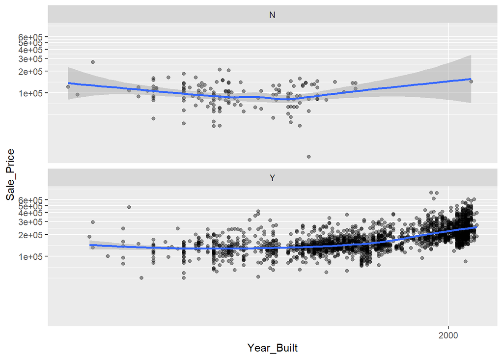

```r
library(MASS)
# get robust linear regression model

ggplot(ames_train,
       aes(x=Year_Built, y=Sale_Price))+
  geom_point(alpha=0.4)+
  scale_x_log10()+
  scale_y_continuous(breaks=price_breaks,
                     trans="log10")+
  facet_wrap(~Central_Air,nrow=2)+
  geom_smooth(method="loess")
```

It appears as though the relationship between the year built and the sale price is somewhat different for the two groups:

- When there is no AC, the trend as perhaps flat or slighlt decreasing
- With AC, there is a linear increasing trend or is perhaps slighlty quadratic with some outliers at the low end.

```r
mod1 <- lm(log10(Sale_Price)~Year_Built+Central_Air, data=ames_train)
mod2 <- lm(log10(Sale_Price)~Year_Built+Central_Air+Year_Built:Central_Air, data=ames_train)
anova(mod1, mod2)
```

```
## Analysis of Variance Table
##
## Model 1: log10(Sale_Price) ~ Year_Built + Central_Air
## Model 2: log10(Sale_Price) ~ Year_Built + Central_Air + Year_Built:Central_Air
##   Res.Df    RSS Df Sum of Sq      F    Pr(>F)
## 1   2196 41.349
## 2   2195 40.239  1    1.1106 60.583 1.078e-14 ***
## ---
## Signif. codes:  0 '***' 0.001 '**' 0.01 '*' 0.05 '.' 0.1 ' ' 1
```

## Interactions in Recipes

We first create the dummy variables for the qualitative predictor (central_Air) then use a fomula to create the interaction using the `:` operator in an additional step:

```r
recipe(Sale_Price~Year_Built+Central_Air,data=ames_train) %>%
  step_log(Sale_Price) %>%
  step_dummy(Central_Air) %>%
  step_interact(~starts_with("Central_Air"):Year_Built) %>%
  prep(training=ames_train,retain=TRUE) %>%
  juice() %>%
  slice(153:157)
```

```
## # A tibble: 5 x 4
##   Year_Built Sale_Price Central_Air_Y Central_Air_Y_x_Year_Built
##        <int>      <dbl>         <dbl>                      <dbl>
## 1       1912       12.0             1                       1912
## 2       1930       10.9             0                          0
## 3       1900       11.8             1                       1900
## 4       1959       12.1             1                       1959
## 5       1917       11.6             0                          0
```

```r
# seelect a few rows with different values
```

# Adding `Recipes` to our `rsample` workflows

## Resampling methods

These are additional data splittig schemes that are applied to the *training* set.

They attempt to simulate slightly different versions of the training set. These versions of the original are split into two model subsets.

This process is repeated many times. There are different flavors or resampling but we will focus on two methods.

## V-Fold cross-validation

Here, we randomly split the training data into V distinct blocks of roughly equal size. - We leave out the first block of analysis data and fit a model - This model is used to predict the held-out block of assessment data - We continue this process until we have predicted all V assessment blokcs.

The final performance is based on the hold-out predictions by *averaging* the statistics from the V blocks. V is usually taken to be 5 or 10 and leave one out cross-validation has each sample as a block.

## Resampling and preprocessing

It is important to realize that almost all preprocessing steps that involve estimation should be bundled inside of the resampling process so that the performance estimates are not biased.

- **Bad**: preprocess the data, resample the model
- **Good**: resample the preprocessing and modeling

Also, 1) avoid *information leakage* by having all operations in the modeling process occur only on the training set. 2) Plus, do not reestimate anything on the test set. For example, to center new data, the training set mean is used.